# Dog Management in Auckland

Tom Saunders

2023-12-27

Over the last couple of years, a national rise in dog attacks have resulted in the deaths of people in [Pānguru](https://www.rnz.co.nz/news/national/472476/fatal-northland-dog-attack-victim-s-family-want-answers-from-boarder) and [Moerewa](https://www.rnz.co.nz/news/national/500060/community-shocked-after-fatal-dog-attack-in-moerewa), the mauling of [children](https://www.tvnz.co.nz/shows/sunday/clips/unleashed), and the [deaths of pets](https://www.rnz.co.nz/news/national/506338/pets-reportedly-killed-by-roaming-dogs-in-whakatane-over-holiday-period), including [30 cats](https://www.rnz.co.nz/news/national/514637/dog-owners-fined-after-27-cats-killed) in a single South Auckland suburb over the last two months. Recent media stories have drawn attention to the [rising number of attacks](https://www.rnz.co.nz/news/national/514690/auckland-dog-attacks-callouts-for-attacks-on-other-animals-going-up) on people and animals.

Under the [Dog Control Act 1996](https://www.legislation.govt.nz/act/public/1996/0013/latest/whole.html#DLM374410) local territorial authorities are responsible for enacting and enforcing bylaws to minimise the danger and nuisance caused by dogs to the public. The Act also requires local authorities to report statistics and data relating to dog control activities. Auckland Council operates a regional Animal Management unit and provides data relating to it’s activities within [annual reports](https://www.aucklandcouncil.govt.nz/plans-projects-policies-reports-bylaws/our-policies/Pages/policy-on-dogs.aspx).

The following analyses were performed on a dataset compiled from these annual reports starting in 2014. The complete dataset, and R code used to perform all the analyses, is available [here](https://github.com/tesaunders/dog-control).

## Dogs

### Number of Dogs

The number of known dogs has increased dramatically since 2020. Note: the drop in 2018 reflects work to remove duplicate entries from the register.

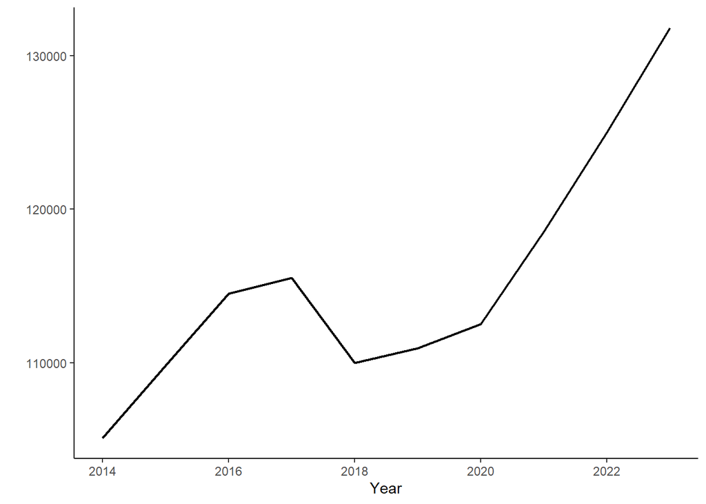

### Registrations

The proportion of dogs registered has started to fall sharply since 2020. Note: The drop in 2017 was the result of work to remove duplicate entries from the register.

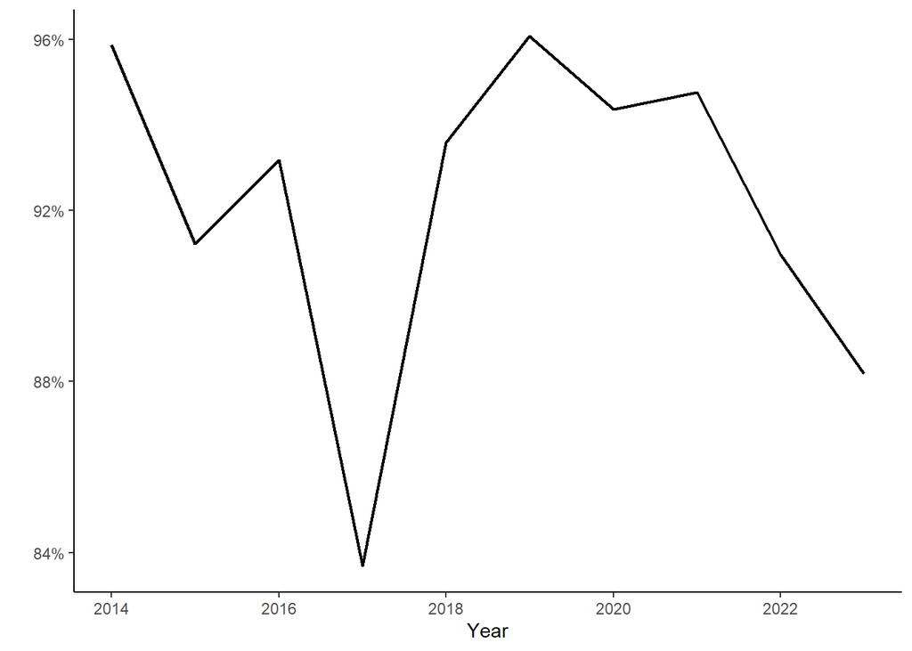

### Roaming dogs

The number of roaming dogs has increased by over 70% since 2021.

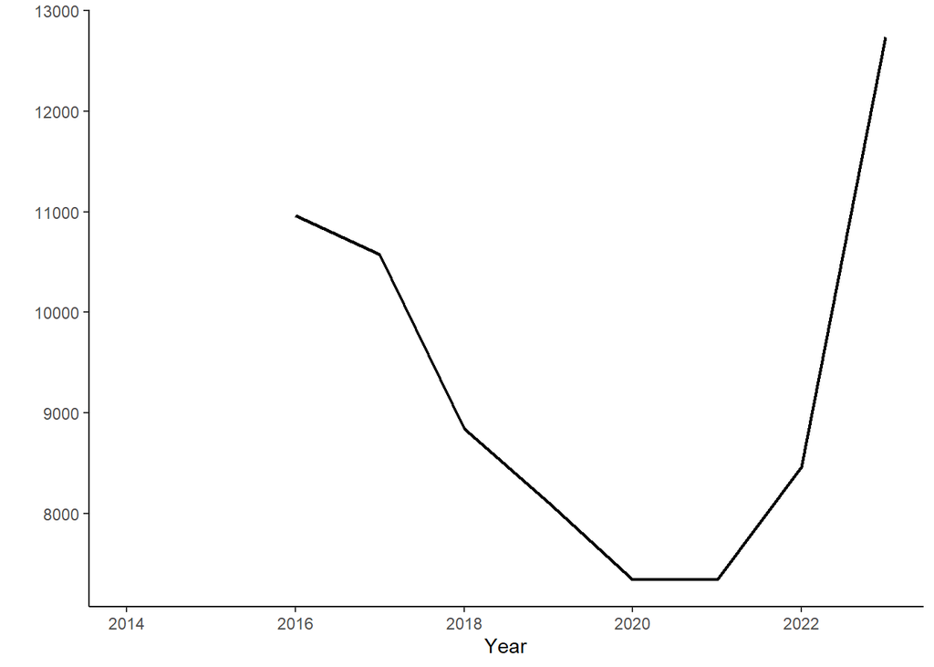

## Attacks

### Attacks on People

The number of dog attacks on people has increased by a whopping 60% since 2021.

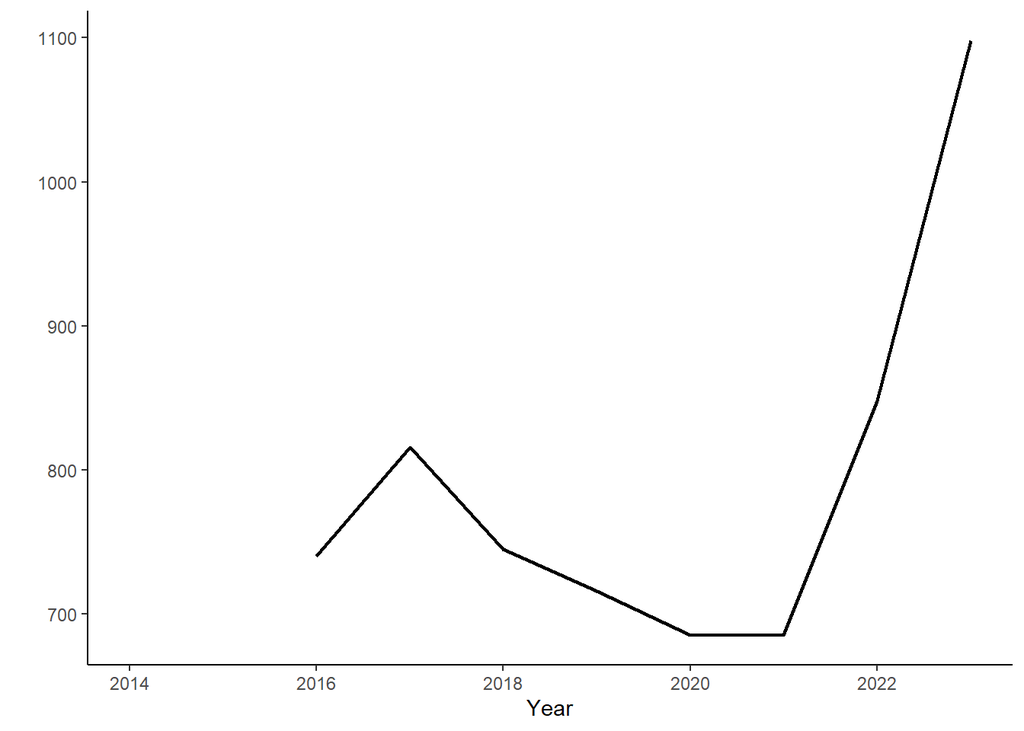

### Aggression

The number of responses to dogs aggressive to people and animals, and attacks on animals, are all on the increase.

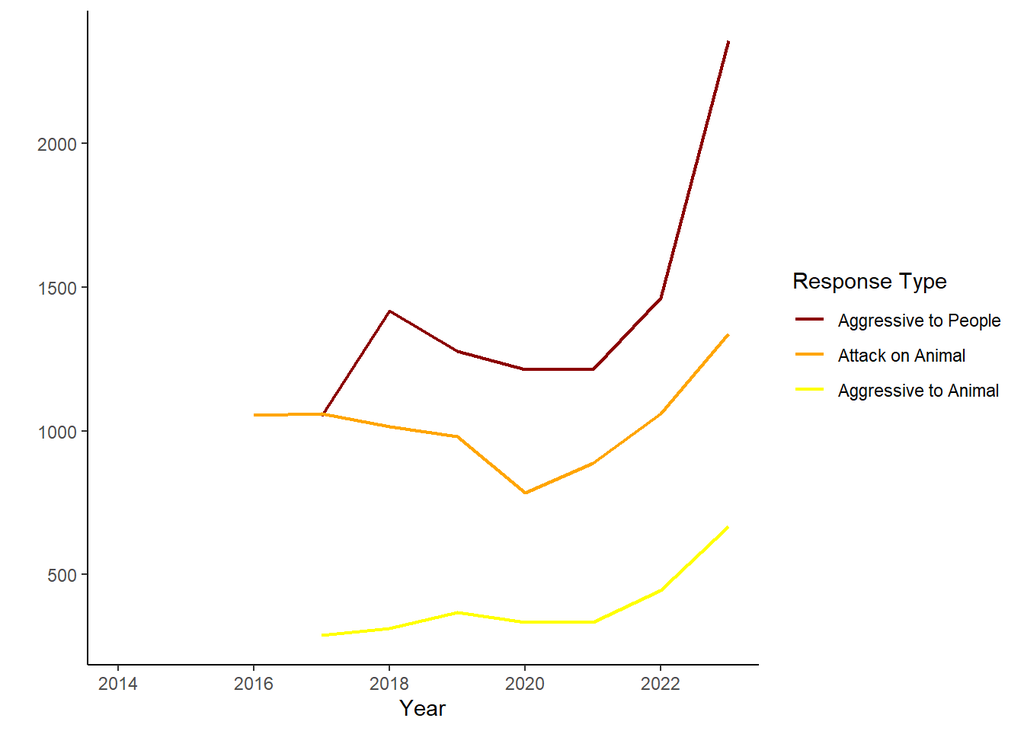

### Menacing Dogs

The proportion of dogs classified as menacing has more than doubled since 2014.

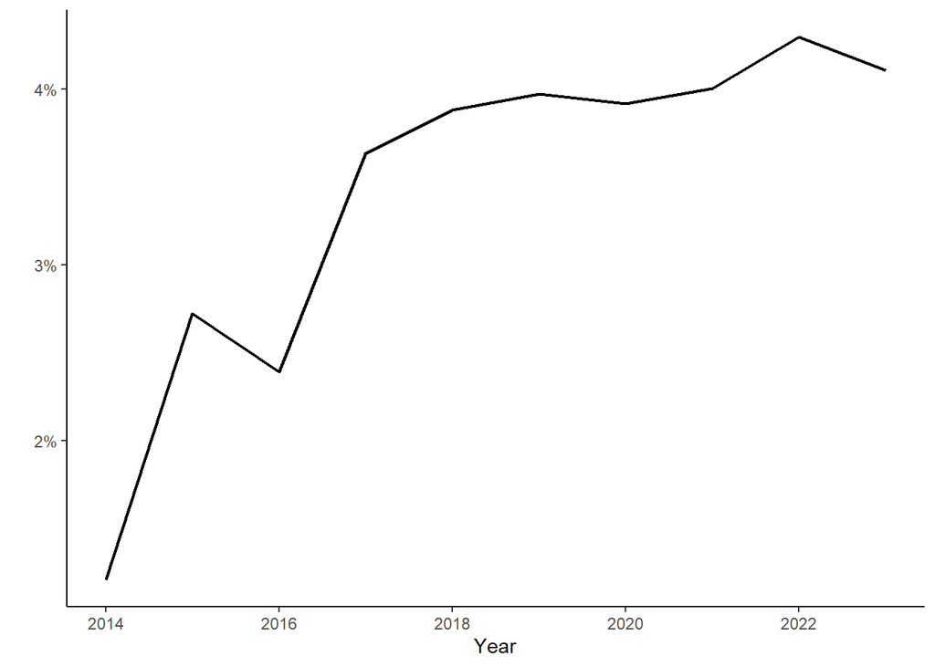

## Owners

### Number of Owners

Dog ownership continues to trend upward since lockdowns.

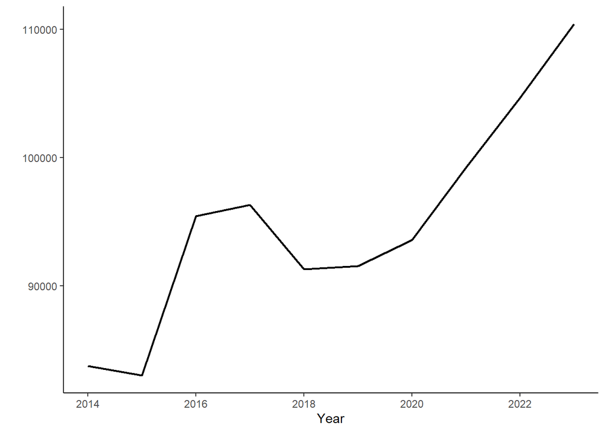

### Sanctioned Owners

There are now 6 times more owners classified as ‘probationary’ or ‘disqualified’ since 2020.

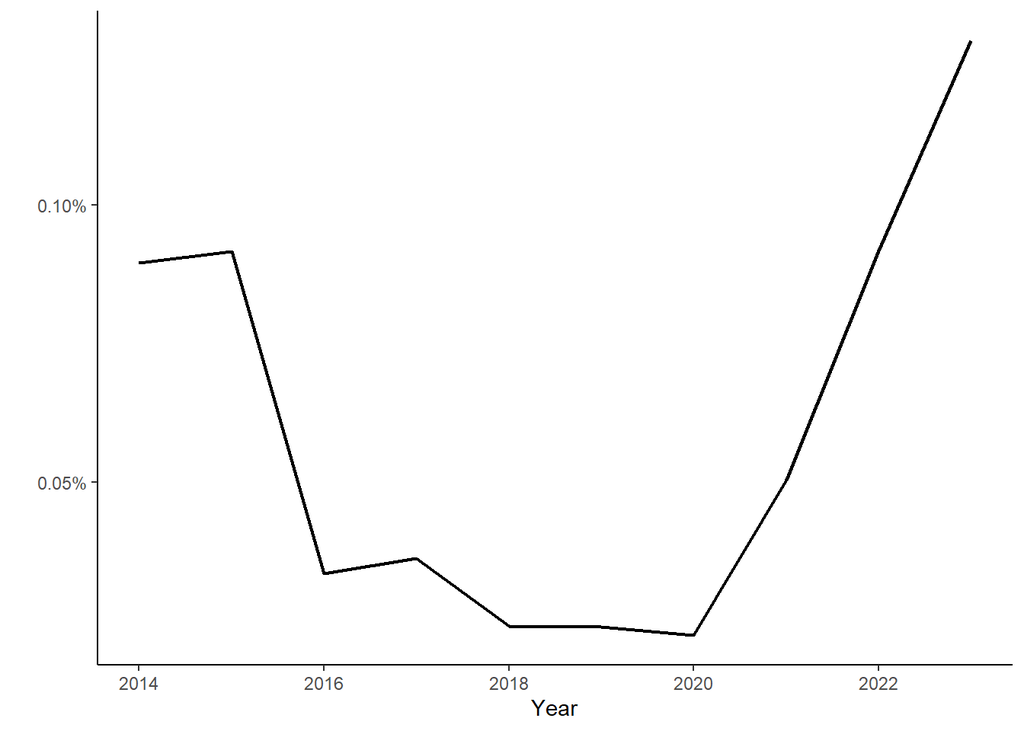

## Responses

### Responses over time

As the overall number of Animal Management responses decreases over time, the share of high priority responses is increasing.

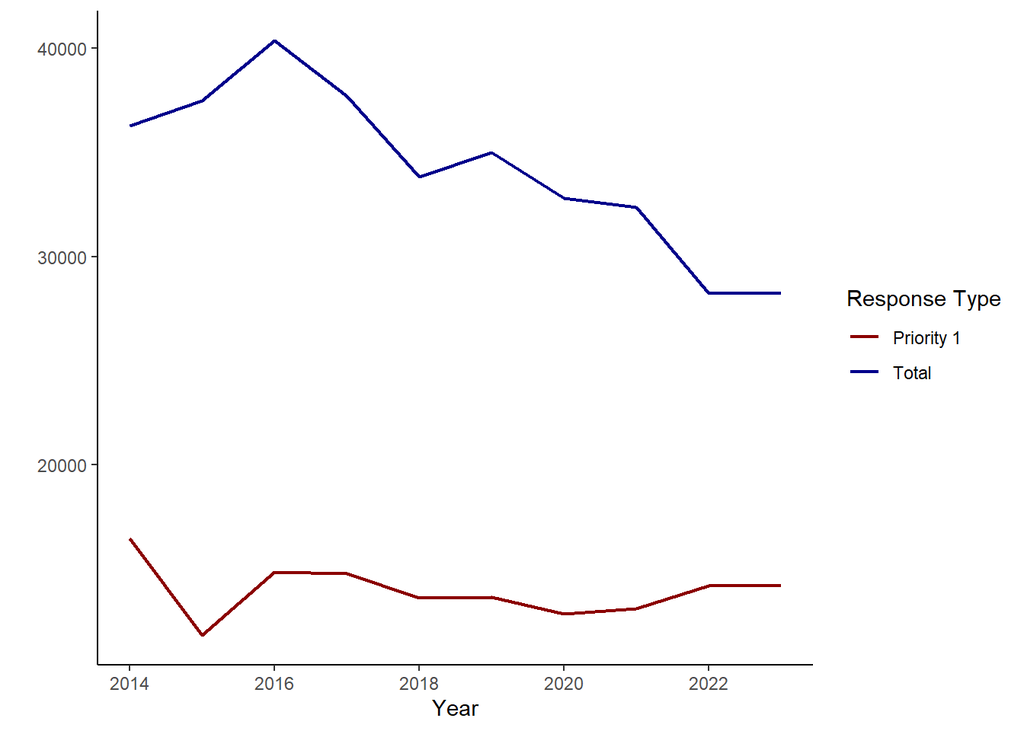

## Impounds

### Impounded Dogs

The proportion of known dogs impounded each year was declining, but has started to rise again since COVID-19 lockdowns.

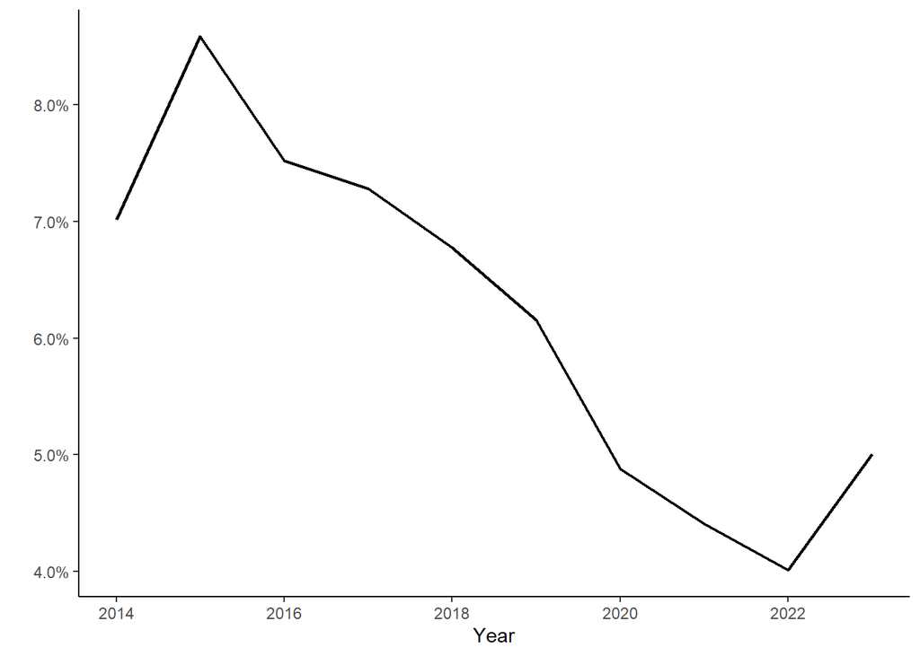

### Claimed/Returned to Owner

The proportion of impounded dogs returned to their owner increased to around 70% in 2021, but has since fallen sharply.

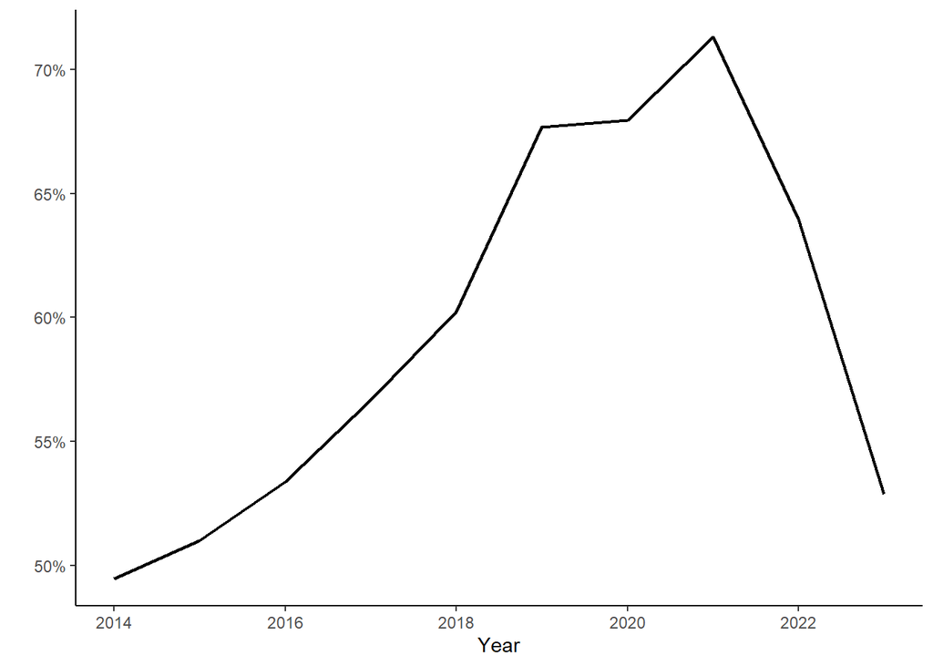

### Euthanized

The proportion of impounded dogs euthanized has increased sharply since 2021.

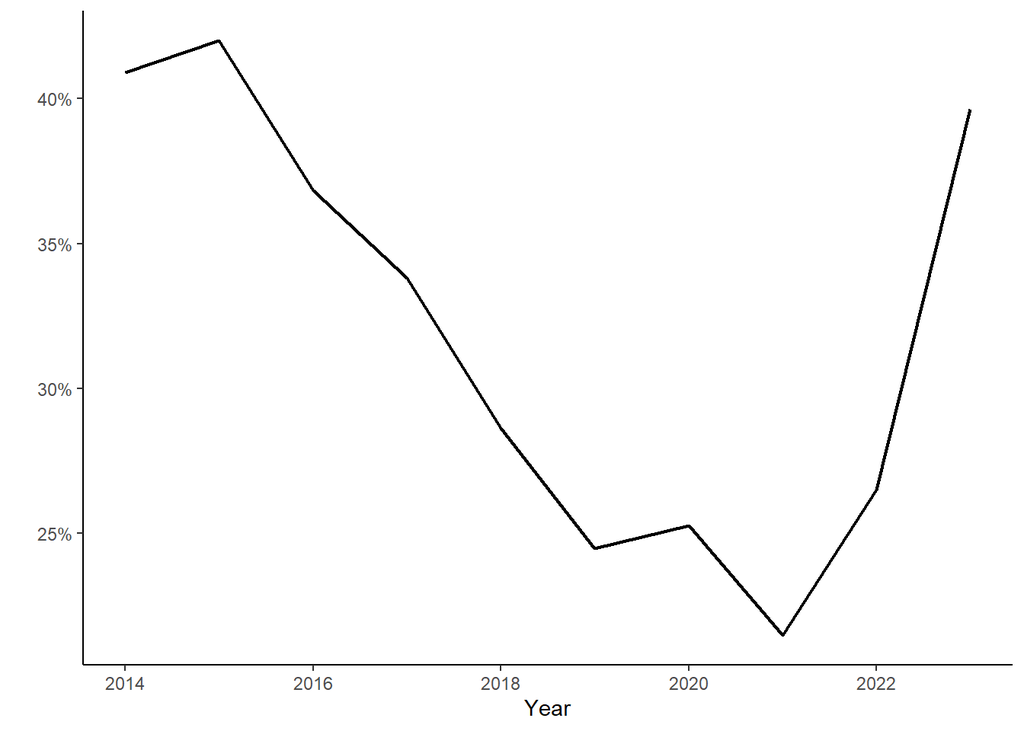

### Adopted/Rescued

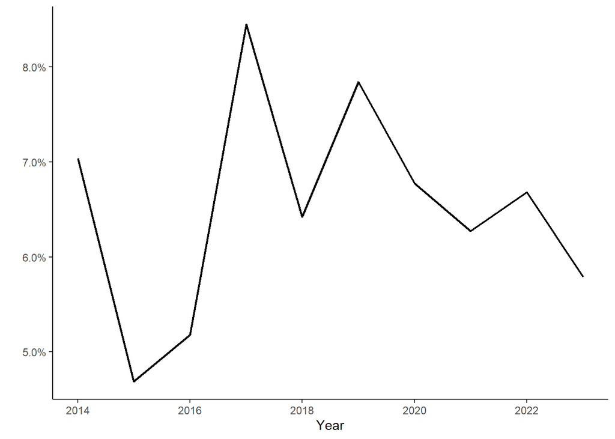

## Enforcement

### Infringements Issued

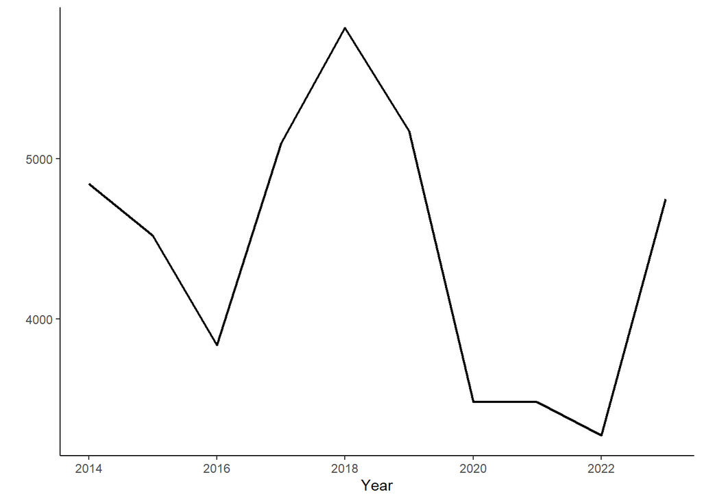

### Prosecutions

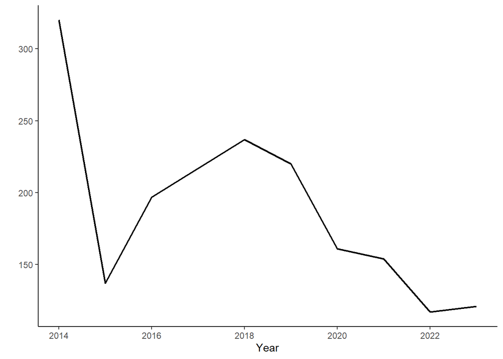

## Resourcing

### Staff vs Dogs

The ratio of known dogs to Animal Management staff has increased over time.

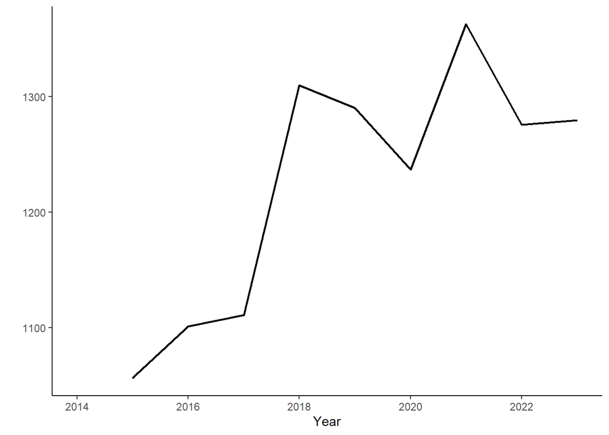

### Animal Management Officers

The proportion of Animal Management staff made up of Animal Management Officers (field staff) has increased since 2021.

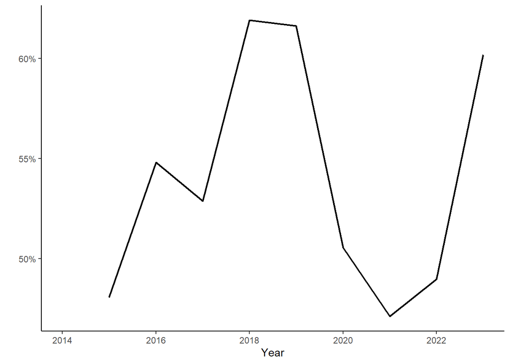

### Expenditure

The budget allocated to Animal Management has not increased anywhere near the rate of the increase in numbers of dogs.

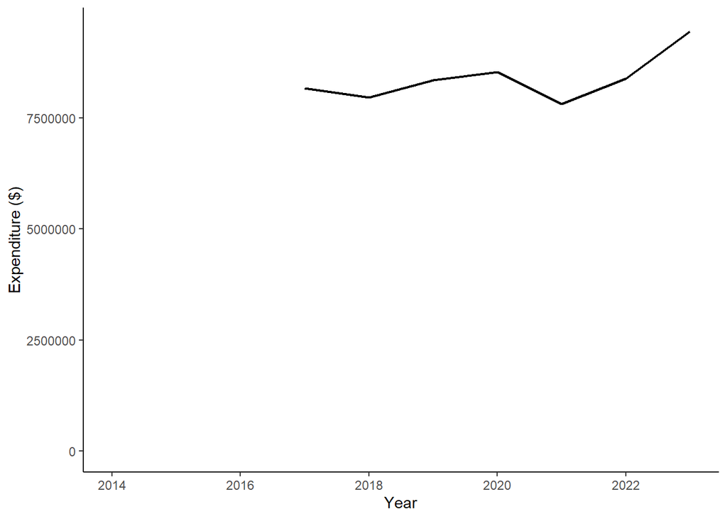